# Data Science and Business Analytics Intern @ The Sparks Foundation

# #GRIPOct2021 #TSF

## Problem Statement - Perform exploratory Data Analysis on dataset of IPL

### Dataset - http://bit.ly/34SRn3b

```python
import pandas as pd
import numpy as np
import matplotlib.pyplot as mpl
import seaborn as sns
import warnings
warnings.filterwarnings('ignore')
```

```python
df_matches=pd.read_csv('matches.csv')
df_matches.head()
```

|  | id | season | city | date | team1 | team2 | toss_winner | toss_decision | result | dl_applied | winner | win_by_runs | win_by_wickets | player_of_match | venue | umpire1 | umpire2 | umpire3 |
| --- | --- | --- | --- | --- | --- | --- | --- | --- | --- | --- | --- | --- | --- | --- | --- | --- | --- | --- |
| 0 | 1 | 2017 | Hyderabad | 2017-04-05 | Sunrisers Hyderabad | Royal Challengers Bangalore | Royal Challengers Bangalore | field | normal | 0 | Sunrisers Hyderabad | 35 | 0 | Yuvraj Singh | Rajiv Gandhi International Stadium, Uppal | AY Dandekar | NJ Llong | NaN |
| 1 | 2 | 2017 | Pune | 2017-04-06 | Mumbai Indians | Rising Pune Supergiant | Rising Pune Supergiant | field | normal | 0 | Rising Pune Supergiant | 0 | 7 | SPD Smith | Maharashtra Cricket Association Stadium | A Nand Kishore | S Ravi | NaN |
| 2 | 3 | 2017 | Rajkot | 2017-04-07 | Gujarat Lions | Kolkata Knight Riders | Kolkata Knight Riders | field | normal | 0 | Kolkata Knight Riders | 0 | 10 | CA Lynn | Saurashtra Cricket Association Stadium | Nitin Menon | CK Nandan | NaN |
| 3 | 4 | 2017 | Indore | 2017-04-08 | Rising Pune Supergiant | Kings XI Punjab | Kings XI Punjab | field | normal | 0 | Kings XI Punjab | 0 | 6 | GJ Maxwell | Holkar Cricket Stadium | AK Chaudhary | C Shamshuddin | NaN |
| 4 | 5 | 2017 | Bangalore | 2017-04-08 | Royal Challengers Bangalore | Delhi Daredevils | Royal Challengers Bangalore | bat | normal | 0 | Royal Challengers Bangalore | 15 | 0 | KM Jadhav | M Chinnaswamy Stadium | NaN | NaN | NaN |

```python
df_deliveries=pd.read_csv('deliveries.csv')
df_deliveries.head()
```

|  | match_id | inning | batting_team | bowling_team | over | ball | batsman | non_striker | bowler | is_super_over | ... | bye_runs | legbye_runs | noball_runs | penalty_runs | batsman_runs | extra_runs | total_runs | player_dismissed | dismissal_kind | fielder |
| --- | --- | --- | --- | --- | --- | --- | --- | --- | --- | --- | --- | --- | --- | --- | --- | --- | --- | --- | --- | --- | --- |
| 0 | 1 | 1 | Sunrisers Hyderabad | Royal Challengers Bangalore | 1 | 1 | DA Warner | S Dhawan | TS Mills | 0 | ... | 0 | 0 | 0 | 0 | 0 | 0 | 0 | NaN | NaN | NaN |
| 1 | 1 | 1 | Sunrisers Hyderabad | Royal Challengers Bangalore | 1 | 2 | DA Warner | S Dhawan | TS Mills | 0 | ... | 0 | 0 | 0 | 0 | 0 | 0 | 0 | NaN | NaN | NaN |
| 2 | 1 | 1 | Sunrisers Hyderabad | Royal Challengers Bangalore | 1 | 3 | DA Warner | S Dhawan | TS Mills | 0 | ... | 0 | 0 | 0 | 0 | 4 | 0 | 4 | NaN | NaN | NaN |
| 3 | 1 | 1 | Sunrisers Hyderabad | Royal Challengers Bangalore | 1 | 4 | DA Warner | S Dhawan | TS Mills | 0 | ... | 0 | 0 | 0 | 0 | 0 | 0 | 0 | NaN | NaN | NaN |
| 4 | 1 | 1 | Sunrisers Hyderabad | Royal Challengers Bangalore | 1 | 5 | DA Warner | S Dhawan | TS Mills | 0 | ... | 0 | 0 | 0 | 0 | 0 | 2 | 2 | NaN | NaN | NaN |

5 rows × 21 columns

```python
df_data=df_matches[['id','season','winner']]
df_finaldata=df_deliveries.merge(df_data, how='inner', left_on='match_id', right_on='id')
df_finaldata
```

|  | match_id | inning | batting_team | bowling_team | over | ball | batsman | non_striker | bowler | is_super_over | ... | penalty_runs | batsman_runs | extra_runs | total_runs | player_dismissed | dismissal_kind | fielder | id | season | winner |
| --- | --- | --- | --- | --- | --- | --- | --- | --- | --- | --- | --- | --- | --- | --- | --- | --- | --- | --- | --- | --- | --- |
| 0 | 1 | 1 | Sunrisers Hyderabad | Royal Challengers Bangalore | 1 | 1 | DA Warner | S Dhawan | TS Mills | 0 | ... | 0 | 0 | 0 | 0 | NaN | NaN | NaN | 1 | 2017 | Sunrisers Hyderabad |
| 1 | 1 | 1 | Sunrisers Hyderabad | Royal Challengers Bangalore | 1 | 2 | DA Warner | S Dhawan | TS Mills | 0 | ... | 0 | 0 | 0 | 0 | NaN | NaN | NaN | 1 | 2017 | Sunrisers Hyderabad |
| 2 | 1 | 1 | Sunrisers Hyderabad | Royal Challengers Bangalore | 1 | 3 | DA Warner | S Dhawan | TS Mills | 0 | ... | 0 | 4 | 0 | 4 | NaN | NaN | NaN | 1 | 2017 | Sunrisers Hyderabad |
| 3 | 1 | 1 | Sunrisers Hyderabad | Royal Challengers Bangalore | 1 | 4 | DA Warner | S Dhawan | TS Mills | 0 | ... | 0 | 0 | 0 | 0 | NaN | NaN | NaN | 1 | 2017 | Sunrisers Hyderabad |
| 4 | 1 | 1 | Sunrisers Hyderabad | Royal Challengers Bangalore | 1 | 5 | DA Warner | S Dhawan | TS Mills | 0 | ... | 0 | 0 | 2 | 2 | NaN | NaN | NaN | 1 | 2017 | Sunrisers Hyderabad |
| ... | ... | ... | ... | ... | ... | ... | ... | ... | ... | ... | ... | ... | ... | ... | ... | ... | ... | ... | ... | ... | ... |
| 179073 | 11415 | 2 | Chennai Super Kings | Mumbai Indians | 20 | 2 | RA Jadeja | SR Watson | SL Malinga | 0 | ... | 0 | 1 | 0 | 1 | NaN | NaN | NaN | 11415 | 2019 | Mumbai Indians |
| 179074 | 11415 | 2 | Chennai Super Kings | Mumbai Indians | 20 | 3 | SR Watson | RA Jadeja | SL Malinga | 0 | ... | 0 | 2 | 0 | 2 | NaN | NaN | NaN | 11415 | 2019 | Mumbai Indians |
| 179075 | 11415 | 2 | Chennai Super Kings | Mumbai Indians | 20 | 4 | SR Watson | RA Jadeja | SL Malinga | 0 | ... | 0 | 1 | 0 | 1 | SR Watson | run out | KH Pandya | 11415 | 2019 | Mumbai Indians |
| 179076 | 11415 | 2 | Chennai Super Kings | Mumbai Indians | 20 | 5 | SN Thakur | RA Jadeja | SL Malinga | 0 | ... | 0 | 2 | 0 | 2 | NaN | NaN | NaN | 11415 | 2019 | Mumbai Indians |
| 179077 | 11415 | 2 | Chennai Super Kings | Mumbai Indians | 20 | 6 | SN Thakur | RA Jadeja | SL Malinga | 0 | ... | 0 | 0 | 0 | 0 | SN Thakur | lbw | NaN | 11415 | 2019 | Mumbai Indians |

179078 rows × 24 columns

```python
df_matches.columns.values
```

```
array(['id', 'season', 'city', 'date', 'team1', 'team2', 'toss_winner',
       'toss_decision', 'result', 'dl_applied', 'winner', 'win_by_runs',
       'win_by_wickets', 'player_of_match', 'venue', 'umpire1', 'umpire2',
       'umpire3'], dtype=object)
```

```python
most_wins_in_season = df_matches.groupby('season')['winner'].value_counts()
most_wins_in_season
```

```
season  winner
2008    Rajasthan Royals               13
        Kings XI Punjab                10
        Chennai Super Kings             9
        Delhi Daredevils                7
        Mumbai Indians                  7
                                       ..
2019    Kings XI Punjab                 6
        Kolkata Knight Riders           6
        Sunrisers Hyderabad             6
        Rajasthan Royals                5
        Royal Challengers Bangalore     5
Name: winner, Length: 100, dtype: int64
```

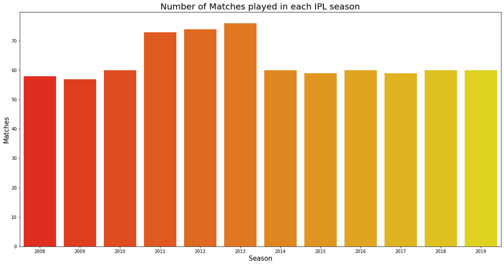

```python
mpl.figure(figsize = (20,10))
sns.countplot('season',data=df_matches,palette="autumn")
mpl.title("Number of Matches played in each IPL season",fontsize=20)
mpl.xlabel("Season",fontsize=15)
mpl.ylabel('Matches',fontsize=15)
mpl.show()
```

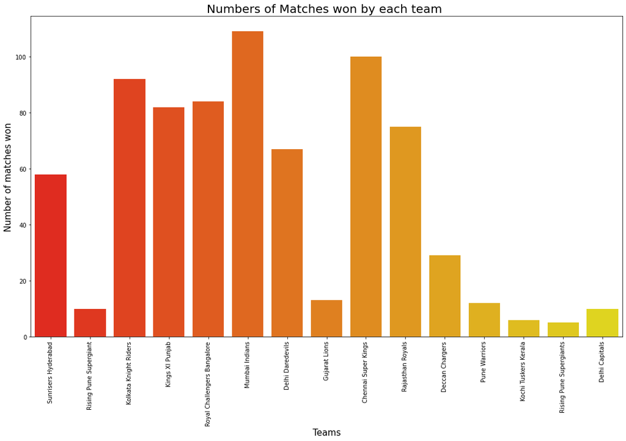

```python
mpl.figure(figsize = (18,10))
sns.countplot(x='winner',data=df_matches, palette='autumn')
mpl.title("Numbers of Matches won by each team ",fontsize=20)
mpl.xticks(rotation=90)
mpl.xlabel("Teams",fontsize=15)
mpl.ylabel("Number of matches won",fontsize=15)
mpl.show()
```

The above plot defines the success rates of all the teams that have contested in the tournament through the years.

- Mumbai Indians is the most successful franchise with most number of wins in the history of the tournament, followed by Chennai Super KIngs and Kolkata Knight Riders respectively.

```python
df_matches['win_by']=np.where(df_matches['win_by_runs']>0,'Won batting first','Won bowling first')
```

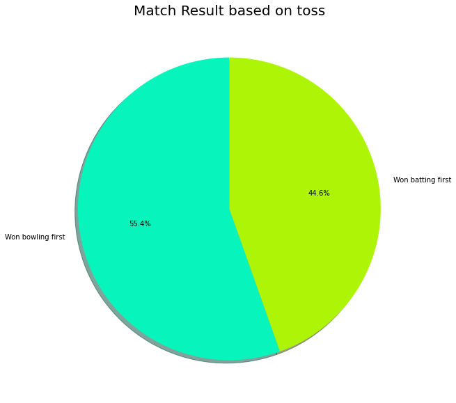

```python
Win=df_matches.win_by.value_counts()
labels=np.array(Win.index)
sizes = Win.values
colors = ['#07F4BD', '#ADF407']
mpl.figure(figsize = (10,10))
mpl.pie(sizes, labels=labels, colors=colors,
        autopct='%1.1f%%', shadow=True,startangle=90)
mpl.title('Match Result based on toss',fontsize=20)
mpl.axis()
mpl.show()
```

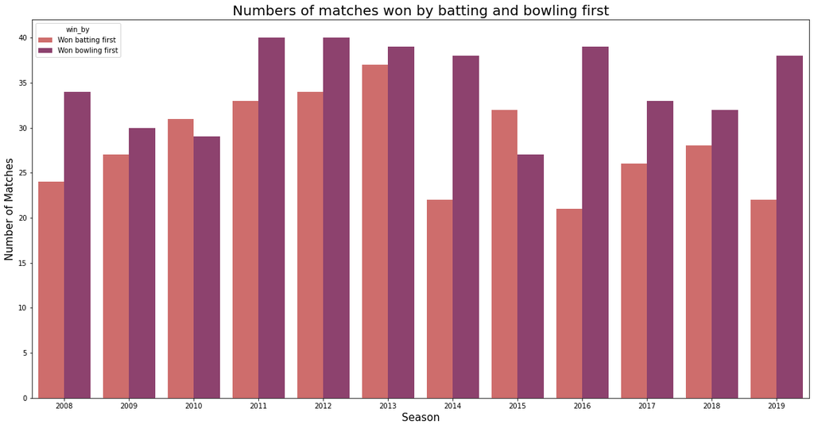

```python
mpl.figure(figsize = (20,10))
sns.countplot('season',hue='win_by',data=df_matches,palette='flare')
mpl.title("Numbers of matches won by batting and bowling first",fontsize=20)
mpl.xlabel("Season",fontsize=15)
mpl.ylabel("Number of Matches",fontsize=15)
mpl.show()
```

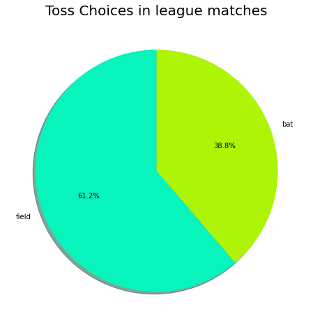

```python
Toss=df_matches.toss_decision.value_counts()
labels=np.array(Toss.index)
sizes = Toss.values
colors = ['#07F4BD', '#ADF407']
mpl.figure(figsize = (10,8))
mpl.pie(sizes, labels=labels, colors=colors,
        autopct='%1.1f%%', shadow=True,startangle=90)
mpl.title('Toss Choices in league matches',fontsize=20)
mpl.axis()
mpl.show()
```

[figure not shown]

```python
mpl.figure(figsize = (20,10))
sns.countplot('season', hue='toss_decision',data=df_matches,palette='winter')
mpl.title("Numbers of matches where winner of the toss has gone on to win the match ",fontsize=20)
mpl.xlabel("Season",fontsize=15)
mpl.ylabel("Number of matches",fontsize=15)
mpl.show()
```

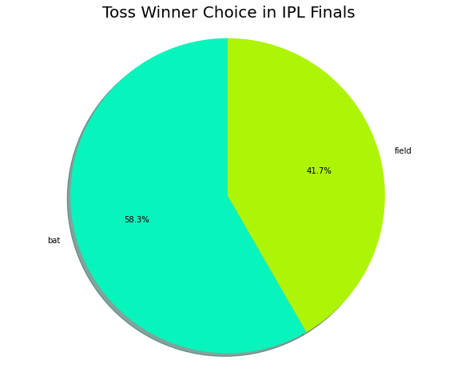

```python
final_matches=df_matches.drop_duplicates(subset=['season'], keep='last')
final_matches[['season','winner']].reset_index(drop=True).sort_values('season')

Toss=final_matches.toss_decision.value_counts()
labels=np.array(Toss.index)
sizes = Toss.values
colors = ['#07F4BD', '#ADF407']
mpl.figure(figsize = (10,8))
mpl.pie(sizes, labels=labels, colors=colors,
        autopct='%1.1f%%', shadow=True,startangle=90)
mpl.title('Toss Winner Choice in IPL Finals',fontsize=20)
mpl.axis('equal')
mpl.show()
```

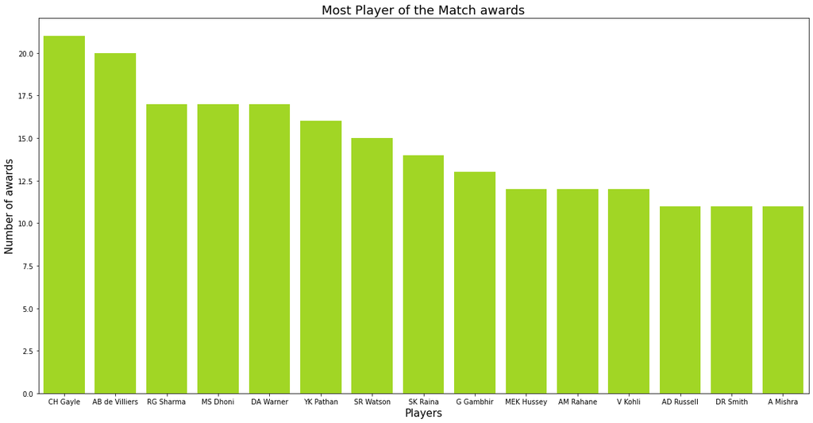

```python
mpl.figure(figsize = (20,10))
mom = df_matches.player_of_match.value_counts()[:15]
ax=sns.barplot(x=mom.index, y=mom, color='#ADF407')
ax.set_ylabel('Number of awards', fontsize=15)
ax.set_xlabel('Players', fontsize=15)
ax.set_title("Most Player of the Match awards", fontsize=18)
```

- Chris Gayle has won the most number of man of the match awards through the years.

```python
final_matches.groupby(['city','winner']).size()
```

```
city          winner
Bangalore     Kolkata Knight Riders    1
              Sunrisers Hyderabad      1
Chennai       Chennai Super Kings      1
              Kolkata Knight Riders    1
Hyderabad     Mumbai Indians           2
Johannesburg  Deccan Chargers          1
Kolkata       Mumbai Indians           2
Mumbai        Chennai Super Kings      2
              Rajasthan Royals         1
dtype: int64
```

```python
final_matches["winner"].value_counts()
```

```
Mumbai Indians           4
Chennai Super Kings      3
Kolkata Knight Riders    2
Deccan Chargers          1
Rajasthan Royals         1
Sunrisers Hyderabad      1
Name: winner, dtype: int64
```

- Mumbai Indians has won the most number of finals in the history of the tournament.

```python
final_matches[['toss_winner','toss_decision','winner']].reset_index(drop=True)
```

|  | toss_winner | toss_decision | winner |
| --- | --- | --- | --- |
| 0 | Mumbai Indians | bat | Mumbai Indians |
| 1 | Rajasthan Royals | field | Rajasthan Royals |
| 2 | Royal Challengers Bangalore | field | Deccan Chargers |
| 3 | Chennai Super Kings | bat | Chennai Super Kings |
| 4 | Chennai Super Kings | bat | Chennai Super Kings |
| 5 | Chennai Super Kings | bat | Kolkata Knight Riders |
| 6 | Mumbai Indians | bat | Mumbai Indians |
| 7 | Kolkata Knight Riders | field | Kolkata Knight Riders |
| 8 | Chennai Super Kings | field | Mumbai Indians |
| 9 | Sunrisers Hyderabad | bat | Sunrisers Hyderabad |
| 10 | Chennai Super Kings | field | Chennai Super Kings |
| 11 | Mumbai Indians | bat | Mumbai Indians |

- This table states that most number of times, the winner of toss in the final has gone on to win the match as well.

```python
len(final_matches[final_matches['toss_winner']==final_matches['winner']]['winner'])
```

```
9
```

- 9 times the winner of the toss in the final has gone on to win the match as well.

```python
final_matches[['winner','player_of_match']].reset_index(drop=True)
```

|  | winner | player_of_match |
| --- | --- | --- |
| 0 | Mumbai Indians | KH Pandya |
| 1 | Rajasthan Royals | YK Pathan |
| 2 | Deccan Chargers | A Kumble |
| 3 | Chennai Super Kings | SK Raina |
| 4 | Chennai Super Kings | M Vijay |
| 5 | Kolkata Knight Riders | MS Bisla |
| 6 | Mumbai Indians | KA Pollard |
| 7 | Kolkata Knight Riders | MK Pandey |
| 8 | Mumbai Indians | RG Sharma |
| 9 | Sunrisers Hyderabad | BCJ Cutting |
| 10 | Chennai Super Kings | SR Watson |
| 11 | Mumbai Indians | JJ Bumrah |

- Every time, a final has seen a new player of the match emerging on the night of the final.

```python
fours_hit=df_finaldata[df_finaldata['batsman_runs']==4]
fours_hit.groupby('batting_team')['batsman_runs'].agg([('Runs scored by 4s','sum'),('Number of 4s hit','count')])
```

| batting_team | Runs scored by 4s | Number of 4s hit |
| --- | --- | --- |
| Chennai Super Kings | 8772 | 2193 |
| Deccan Chargers | 3828 | 957 |
| Delhi Capitals | 968 | 242 |
| Delhi Daredevils | 8632 | 2158 |
| Gujarat Lions | 1840 | 460 |
| Kings XI Punjab | 9832 | 2458 |
| Kochi Tuskers Kerala | 680 | 170 |
| Kolkata Knight Riders | 9736 | 2434 |
| Mumbai Indians | 10352 | 2588 |
| Pune Warriors | 2100 | 525 |
| Rajasthan Royals | 8140 | 2035 |
| Rising Pune Supergiant | 788 | 197 |
| Rising Pune Supergiants | 684 | 171 |
| Royal Challengers Bangalore | 9440 | 2360 |
| Sunrisers Hyderabad | 5776 | 1444 |

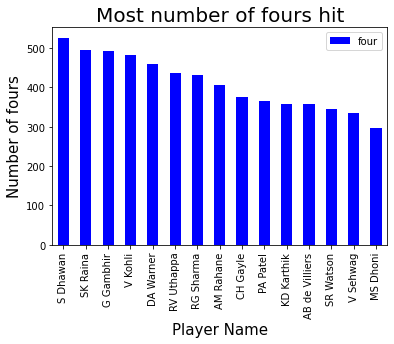

```python
most_fours=fours_hit.groupby('batsman')['batsman_runs'].agg([('four','count')]).reset_index().sort_values('four',ascending=0)
top15=most_fours.iloc[:15,:].plot('batsman','four', kind='bar',color='blue')
mpl.title('Most number of fours hit', fontsize=20)
mpl.xlabel('Player Name', fontsize=15)
mpl.xticks(rotation=90)
mpl.ylabel('Number of fours', fontsize=15)
mpl.show()
```

```python
sixes_hit=df_finaldata[df_finaldata['batsman_runs']==6]
sixes_hit.groupby('batting_team')['batsman_runs'].agg([('Runs scored by sixes','sum'),('Number of sixes hit','count')])
```

| batting_team | Runs scored by sixes | Number of sixes hit |
| --- | --- | --- |
| Chennai Super Kings | 5838 | 973 |
| Deccan Chargers | 2400 | 400 |
| Delhi Capitals | 522 | 87 |
| Delhi Daredevils | 4806 | 801 |
| Gujarat Lions | 930 | 155 |
| Kings XI Punjab | 5856 | 976 |
| Kochi Tuskers Kerala | 318 | 53 |
| Kolkata Knight Riders | 5580 | 930 |
| Mumbai Indians | 6576 | 1096 |
| Pune Warriors | 1176 | 196 |
| Rajasthan Royals | 4086 | 681 |
| Rising Pune Supergiant | 534 | 89 |
| Rising Pune Supergiants | 408 | 68 |
| Royal Challengers Bangalore | 6792 | 1132 |
| Sunrisers Hyderabad | 3198 | 533 |

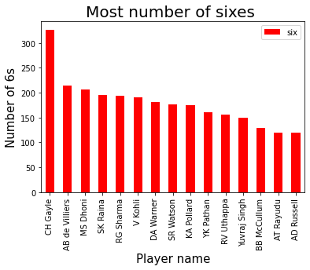

```python
most_sixes=sixes_hit.groupby('batsman')['batsman_runs'].agg([('six','count')]).reset_index().sort_values('six',ascending=0)
top15_6s=most_sixes.iloc[:15,:].plot('batsman','six',kind='bar',color='red')
mpl.title("Most number of sixes ",fontsize=20)
mpl.xticks(rotation=90)
mpl.xlabel("Player name",fontsize=15)
mpl.ylabel("Number of 6s",fontsize=15)
mpl.show()
```

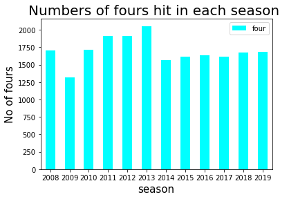

```python
ax=fours_hit.groupby('season')['batsman_runs'].agg([('four','count')]).reset_index()
ax.plot('season','four',kind='bar',color = 'cyan')
mpl.title("Numbers of fours hit in each season ",fontsize=20)
mpl.xticks(rotation=0)
mpl.xlabel("season",fontsize=15)
mpl.ylabel("No of fours",fontsize=15)
mpl.show()
```

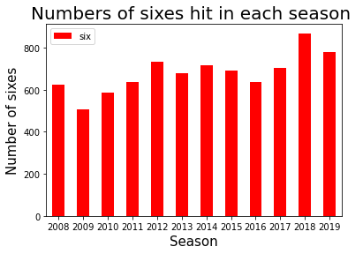

```python
season_6s=sixes_hit.groupby('season')['batsman_runs'].agg([('six','count')]).reset_index()
season_6s.plot('season','six',kind='bar',color = 'red')
mpl.title("Numbers of sixes hit in each season ",fontsize=20)
mpl.xticks(rotation=0)
mpl.xlabel("Season",fontsize=15)
mpl.ylabel("Number of sixes",fontsize=15)
mpl.show()
```

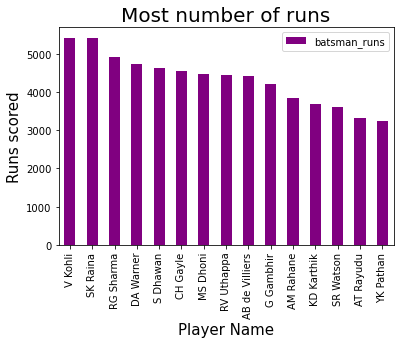

```python
runs=df_deliveries.groupby('batsman')['batsman_runs'].agg(['sum']).reset_index().sort_values('sum',ascending=False).reset_index(drop=True)
runs=runs.rename(columns={'sum':'batsman_runs'})
top15_scorers=runs.iloc[:15,:].plot('batsman','batsman_runs',kind='bar',color='purple')
mpl.title("Most number of runs",fontsize=20)
mpl.xticks(rotation=90)
mpl.xlabel("Player Name",fontsize=15)
mpl.ylabel("Runs scored",fontsize=15)
mpl.show()
```

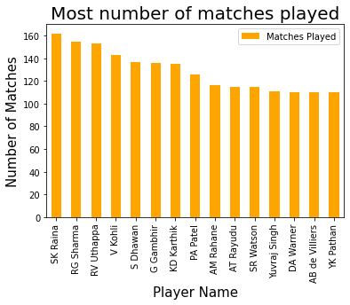

```python
matches_played=df_deliveries[["match_id","player_dismissed"]]
matches_played=matches_played.groupby("player_dismissed")["match_id"].count().reset_index().sort_values(by="match_id",ascending=False).reset_index(drop=True)
matches_played.columns=["Batsman","Matches Played"]
most_appearances=matches_played.iloc[:15,:].plot('Batsman', 'Matches Played',kind='bar',color='orange')
mpl.title("Most number of matches played",fontsize=20)
mpl.xticks(rotation=90)
mpl.xlabel("Player Name",fontsize=15)
mpl.ylabel("Number of Matches",fontsize=15)
mpl.show()
```

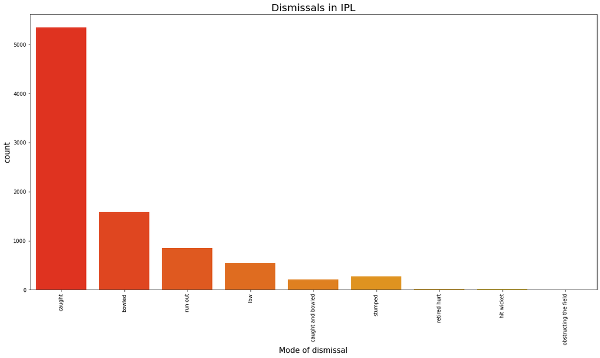

```python
mpl.figure(figsize=(20,10))
ax=sns.countplot(df_deliveries.dismissal_kind, palette='autumn')
mpl.title("Dismissals in IPL",fontsize=20)
mpl.xlabel("Mode of dismissal",fontsize=15)
mpl.ylabel("count",fontsize=15)
mpl.xticks(rotation=90)
mpl.show()
```

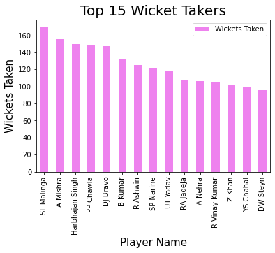

```python
wickets=df_deliveries.dropna(subset=['dismissal_kind'])
wickets=wickets[~wickets['dismissal_kind'].isin(['run out','retired hurt','obstructing the field'])]
wickets_taken=wickets.groupby('bowler')['dismissal_kind'].agg(['count']).reset_index().sort_values('count',ascending=False).reset_index(drop=True)
wickets_taken.columns=['Bowler Name', 'Wickets Taken']
top15_wicket_takers=wickets_taken.iloc[:15].plot('Bowler Name', 'Wickets Taken',kind='bar',color='Violet')
mpl.title("Top 15 Wicket Takers",fontsize=20)
mpl.xticks(rotation=90)
mpl.xlabel("Player Name",fontsize=15)
mpl.ylabel("Wickets Taken",fontsize=15)
mpl.show()
```

# Results and Conclusions

### Leading Run Scorer in IPL

- **Virat Kohli** is the **leading run scorer** in the **history of IPL**.
- **David Warner** is the **highest run getter** amongst all **foreign players**.

### Leading Wicket-taker in IPL

- **Lasith Malinga** is the **leading wicket-taker** in the history of IPL.
- **Amit Mishra** is tops the list of wicket-takers among Indian players.

### Most sixes in IPL

- **Chris Gayle** tops the list of **most number of sixes** through the tournament with a huge margin against the second-placed AB de Villiers.
- **MS Dhoni** is the **leading six-hitter** among **Indian players**.

### Most fours in IPL

- **Shikhar Dhawan** has hit **most number of fours** through the years, marginally surpassing Suresh Raina.
- **David Warner** tops the list of **most number of fours** hit among all the **foreign players**.

### Most successful franchise in IPL

- **Mumbai Indians** is the **most successful franchise** in the history of IPL **winning 4 IPL titles** followed by the 3 titles won by Chennai Super Kings.
- **Royal Challengers Bangalore, Kings XI Punjab and Delhi Capitals** have **not won** a single title.

### Most number of matches won in the tournament

- **Mumbai Indians**, Chennai Super Kings and Kolkata Knight Riders have **won most number of matches** in the history of the tournament.

### Most player of the match awards

- **Chris Gayle** has won most number of man of the match awards, closely followed by AB de Villiers.

### Scoring trend over the years

- Over the years, players have been **more dependent** on **scoring through big hits**, reducing the difference between number of fours and sixes hit through the season.

### Toss dependency in league matches

- There has been a growing **trend** over the years, where the **teams chasing** have gone onto **win** the matches.

### Toss Choices in IPL Finals

- **58.3%** of teams have elected to **bat first** in IPL finals, compared to **41.7%** of teams electing to **field first**.

### Match Result based on toss

- **55.4%** of teams have won the match **bowling first**, while **44.6%** of teams have won **batting first**.